# Data Visualisation in R - Worksheet

#### 2. Scatterplot

Your next task is to create a scatterplot using the `UMAP1` and `UMAP2` columns as x and y coordinates respectively. Colour the points by cell type. Your finished plot should look something like this:

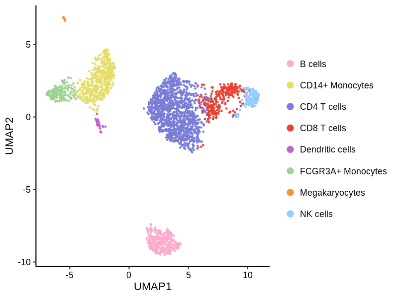

**Some hints:**

- Aesthetics - The x and y axis should represent UMAP1 and UMAP2. Use colour to represent cell type.
- Geometries - Use `geom_point()`.
- Scales - Use `scale_colour_manual()` to change from the default colours to the vector of `cell_colours` I provided for you above.
- Theme - Use `theme_classic()`.

```r
ggplot(data = pbmc_data, aes()) +
  geom_point()
```

Recreate the scatterplot but this time map colour to the expression of CST3. Your finished plot should look something like this:

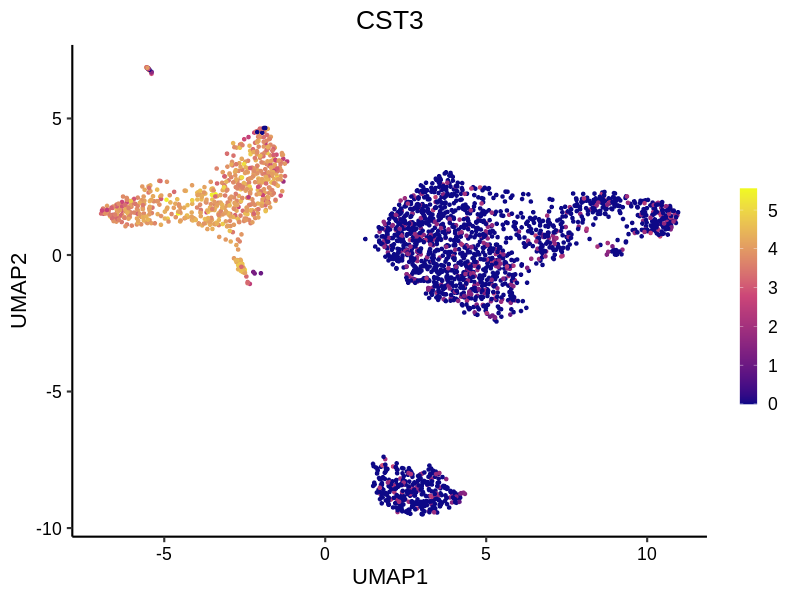

All hints from above remain valid except now colour is representing a continuous variable instead of a categorical variable so you should use `scale_colour_gradientn()` to change from the default colours to the vector of `gradient_colours` that I’ve provided for you.

```r
gradient_colours <- c("#0D0887FF", "#CC4678FF", "#F0F921FF") # colours to use for scale_colour_gradientn()

ggplot(data = pbmc_data, aes()) +
  geom_point()
```

What do you notice about CST3 expression? If you try recreating the plot for CD3E and MS4A1 expression, you’ll notice that these genes are more highly expressed in some clusters than in others.

#### 3. Violin plot

The next task is to visualise the distribution of CST3 expression in different cell types using a violin plot. I like to combine violin plots with a stripchart to show the individual datapoints as it can be helpful when comparing groups of unequal sizes to get an idea of how many datapoints are in each group. Your finished plot should look something like this:

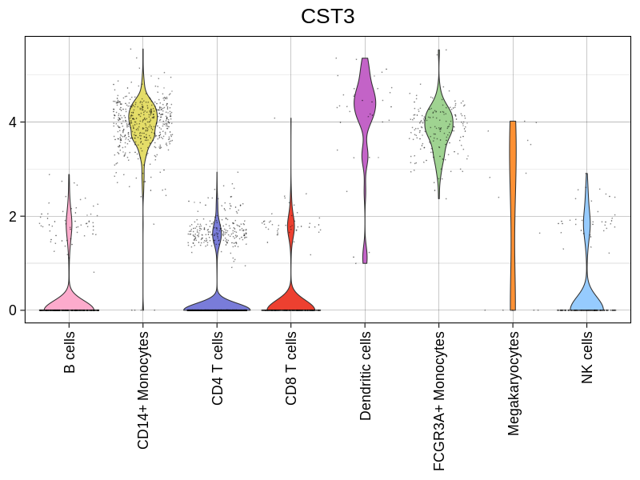

**Some hints:**

- Aesthetics - The x axis should represent cell type, the y axis should represent CST3 expression and the fill of the violins should represent cell type.
- Geometries - Use `geom_violin()` to create the violin plot and `geom_jitter()` to overlay the stripchart. Adjust the size and alpha of the `geom_jitter()` points to make them smaller and more transparent.
- Scales - Use `scale_fill_manual()` to change the fill colours to the vector of `cell_colours` I provided above.
- Theme - Use `theme_linedraw()` instead of the default theme. Use `theme()` to rotate the x axis labels by 90 degrees.

```r
ggplot(pbmc_data, aes()) +
  geom_violin() +
  geom_jitter()
```

*Which cell types have the highest expression of CST3?*

#### 4. Heatmap

```r
cell_types <- as.character(unique(pbmc_data$cell_type)) # create a vector of cell types
genes <- colnames(pbmc_data)[2:13] # create a vector of genes
avg_values <- c() # create an empty vector to store avg. expression values

for(i in cell_types){ # loop through cell types
  sub <- subset(pbmc_data, pbmc_data$cell_type == i) # take a subset of the main dataframe containing only cell type i
  avg_values <- c(avg_values, colMeans(sub[2:13])) # get the average of each of the gene columns in the subsetted dataframe and append them to the avg_values vector
}

avg_exp_df <- data.frame(cell_type = rep(cell_types, each = 12), # create a new dataframe to store the avg expression data
                         gene = rep(genes, 8),
                         avg_exp = avg_values)


# Note: If the code above scares you, there is a simpler way to do it using the dplyr and tidyr R packages. If you have these packages installed you can uncomment the following code and run it to get the same dataframe that's being produced above.

#library(dplyr)
#library(tidyr)
#avg_exp_df <- pbmc_data %>%
#                select(-c(UMAP1, UMAP2)) %>%
#                group_by(cell_type) %>%
#                summarise_all(mean) %>%
#                pivot_longer(cols = 2:13, names_to = 'gene', values_to = 'avg_exp')
```

Use the `head()` function to take a look at the `avg_exp_df` dataframe and make sure you understand what’s in it.

Now we have the data in the correct format to create a heatmap that shows the average expression of each gene in each cell type. Your finished graph should look something like this:

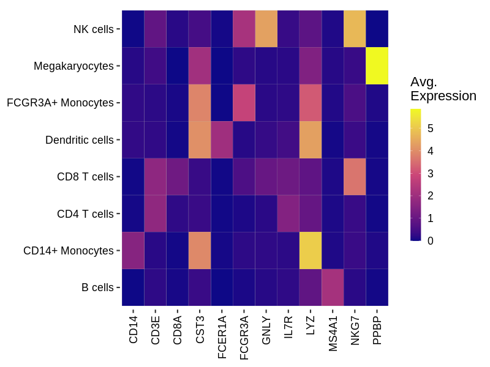

**Some hints:**

- Aesthetics - The x axis should represent gene, the y axis should represent cell type and the fill of the squares should represent the average expression value.
- Geometries - Use `geom_tile()`.
- Scales - Average expression is another continuous variable so use `scale_fill_gradientn()` to change from the default fill colours to the vector of `gradient_colours` I provided above.
- Theme - Use `theme()` to rotate the x axis labels by 90 degrees and change the fill of the panel background from the default grey to white.

```r
ggplot(avg_exp_df, aes()) +
  geom_tile()
```

## Troubleshooting:

- If you have any questions about this tutorial or you encounter any errors, you can post your issues on the [‘Issues’ tab of the GitHub](https://github.com/Genomics-CRT/Data-Science-For-Life-Science/issues). Where possible, include a clear example of your code and the error message that you’re receiving.
- Remember, Google is your friend and most of the answers you’re looking for are probably already on [StackOverflow](https://stackoverflow.com/).
- Feel free to email me any data viz questions - s.ennis6@nuigalway.ie.